# R Notebook

```r
library(brms)
library(tidyverse)
```

```r
library(bayesrules)
library(bayesplot)
library(ggdist)
```

# Datos

```r
#Load data
load('../data/exp1_data.RData')

#Compute influence score based on Zanete and factor column for good/bad news
dexp1 <- dexp1 %>%
  mutate(
    news = factor(ifelse(I==0, "bad", "good")),
    subj = as.integer(subj)
  )
```

# Modelo

## Priors

Evaluamos cuales son los priors presentes en el modelo.

```r
get_prior(update ~
            news * scoreOptimismo * ep +
            news * scoreAnsiedad * ep +
            news * pT +
            (1 | subj),
            data = dexp1,)
```

| prior | class | coef | group | resp | dpar | nlpar | lb | ub | source |
| --- | --- | --- | --- | --- | --- | --- | --- | --- | --- |
|  | b |  |  |  |  |  |  |  | default |
|  | b | ep |  |  |  |  |  |  | default |
|  | b | ep:scoreAnsiedad |  |  |  |  |  |  | default |
|  | b | newsgood |  |  |  |  |  |  | default |
|  | b | newsgood:ep |  |  |  |  |  |  | default |
|  | b | newsgood:ep:scoreAnsiedad |  |  |  |  |  |  | default |
|  | b | newsgood:pT |  |  |  |  |  |  | default |
|  | b | newsgood:scoreAnsiedad |  |  |  |  |  |  | default |
|  | b | newsgood:scoreOptimismo |  |  |  |  |  |  | default |
|  | b | newsgood:scoreOptimismo:ep |  |  |  |  |  |  | default |

[output cut: 9 more lines]

Definimos entonces los priors del modelo.

```r
priors <- c(
  set_prior("normal(0,5)", class = "b")
)
```

Armamos un prior predictive check.

```r
prior_model_1 <- brm(update ~
            news * scoreOptimismo * ep +
            news * scoreAnsiedad * ep +
            news * pT +
            (1 | subj),
            data = dexp1,
            seed = 1234, # for reproducibility
            cores = 4, chains = 4,
            iter = 10000,
            sample_prior = 'only',
            prior = priors,
            file = "model_fits/Exp1PriorPredictive"
            )
```

Chequeamos las predicciones del modelo.

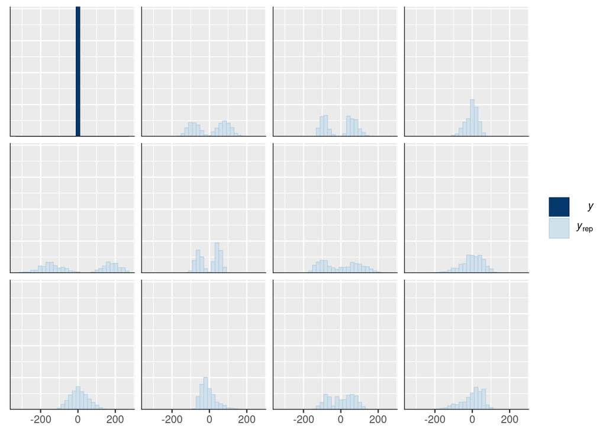

```r
bayesplot::ppc_hist(
  dexp1$update,
  brms::posterior_predict(prior_model_1, ndraws = 11)
)
```

El problema con este prior predictive check es que los valores de la variable de respuesta se salen del rango esperado. La variable de respuesta `update` no puede estar por encima de 1 ni por debajo de -1.

Procedemos adelante y generamos el modelo con los priors definidos anteriormente.

# Model building

```r
#Load data
load('../data/exp1_data.RData')

#Compute factor column for good/bad news
dexp1 <- dexp1 %>%
  mutate(
    news = factor(ifelse(I==0, "bad", "good")),
    subj = as.integer(subj)
  )

update_model <- brm(update ~
                news * scoreOptimismo * ep +
                news * scoreAnsiedad * ep +
                news * pT +
                (1 | subj),
              data = dexp1,
              seed = 1234, # for reproducibility
              cores = 4, chains = 4,
              prior = priors,
              iter = 10000,
              file = "model_fits/FitExp1"
)

update_model_parameters <- variables(update_model)
update_model_params_other <- update_model_parameters[
  !stringr::str_detect(update_model_parameters, 'b_|subj')
]
```

# Diagnosticos

Antes de proseguir chequeamos los diagnosticos del modelo

## Trace

### Fixed

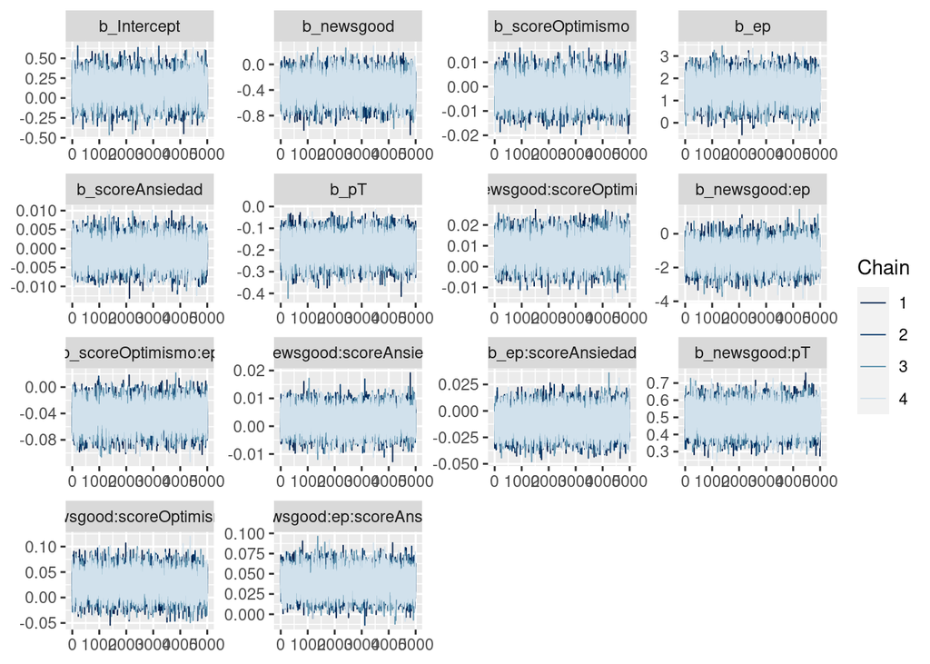

```r
mcmc_trace(update_model, pars = vars(contains('b_')))
```

### Random

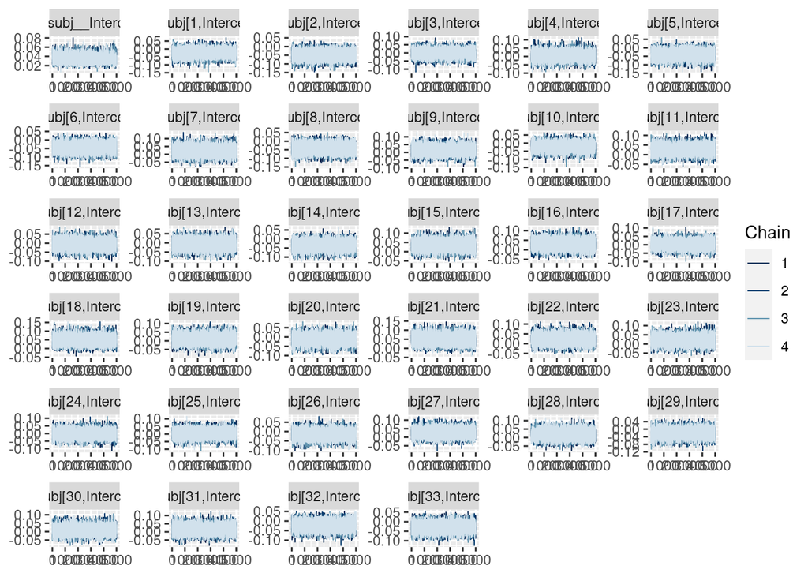

```r
mcmc_trace(update_model, pars = vars(contains('subj')))
```

### Other

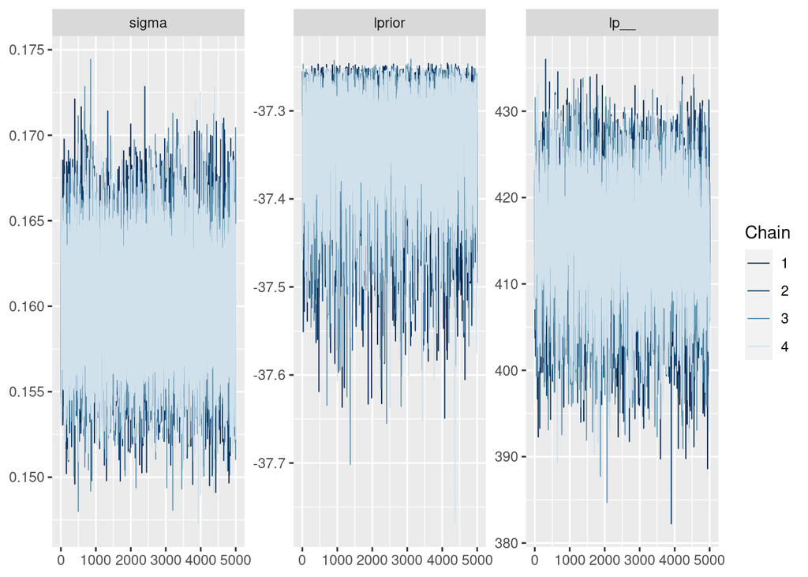

```r
mcmc_trace(update_model, pars = update_model_params_other)
```

## Dens

### Fixed

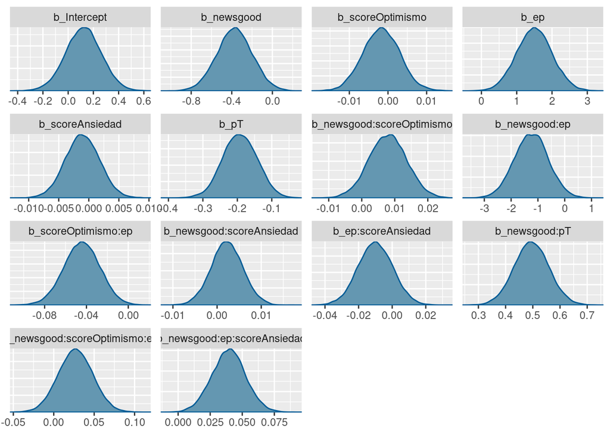

```r
mcmc_dens(update_model, pars = vars(contains('b_')))
```

### Random

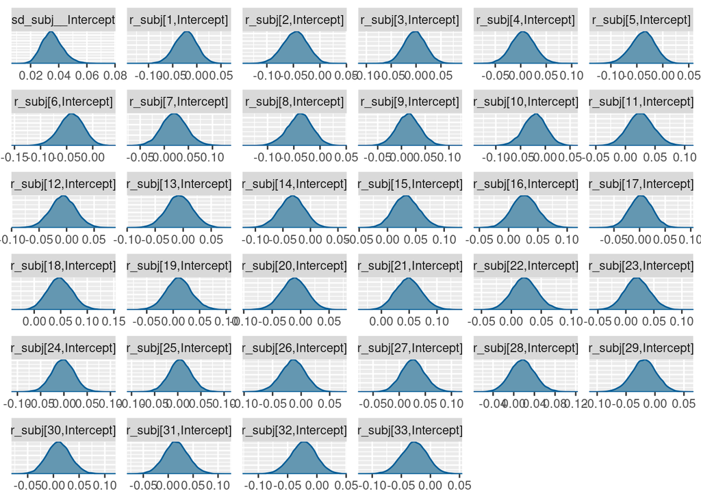

```r
mcmc_dens(update_model, pars = vars(contains('subj')))
```

### Other

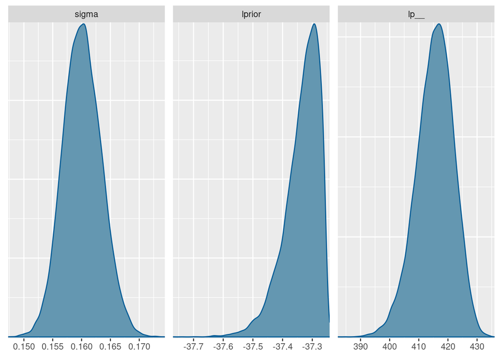

```r
mcmc_dens(update_model, pars = update_model_params_other)
```

## Dens overlay

### Fixed

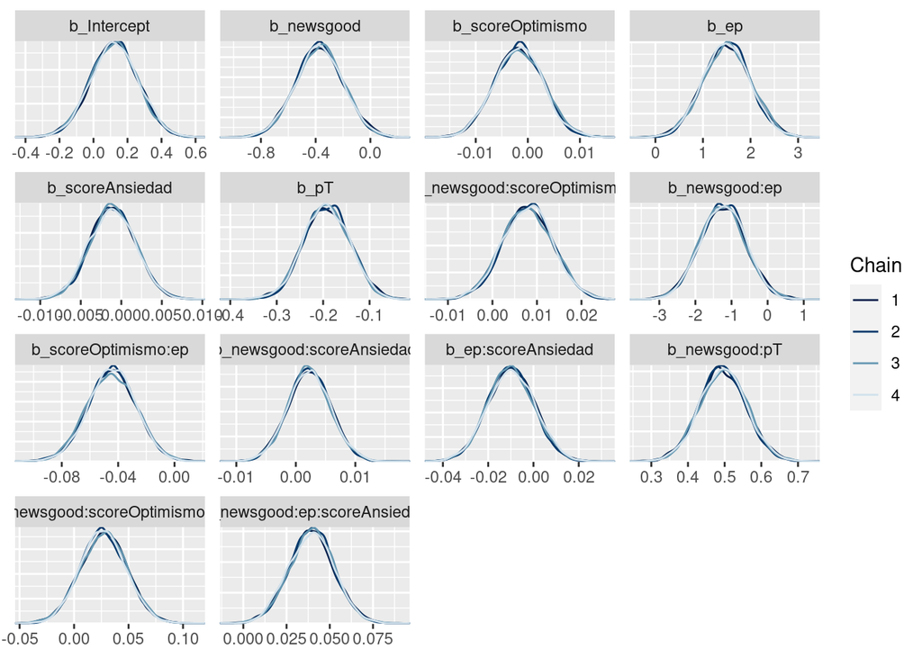

```r
mcmc_dens_overlay(update_model, pars = vars(contains('b_')))
```

### Random

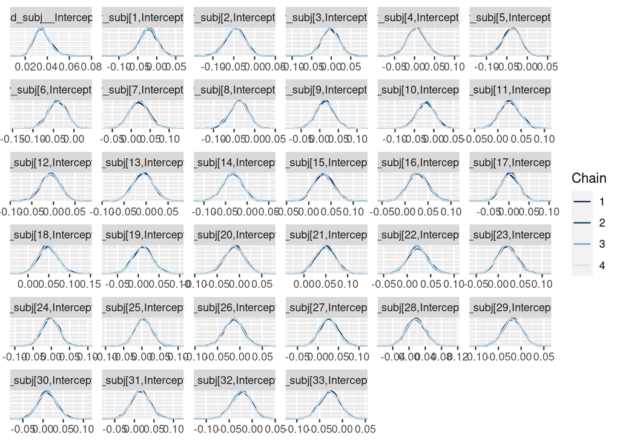

```r
mcmc_dens_overlay(update_model, pars = vars(contains('subj')))
```

### Other

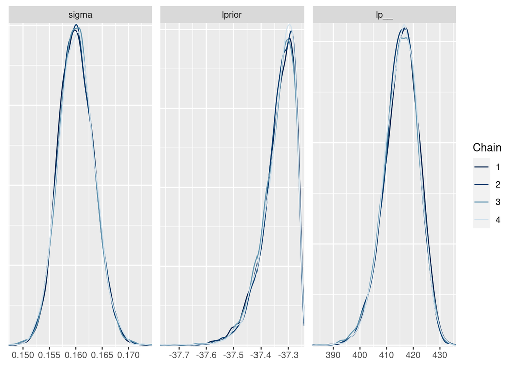

```r
mcmc_dens_overlay(update_model, pars = update_model_params_other)
```

## Autocorrelation

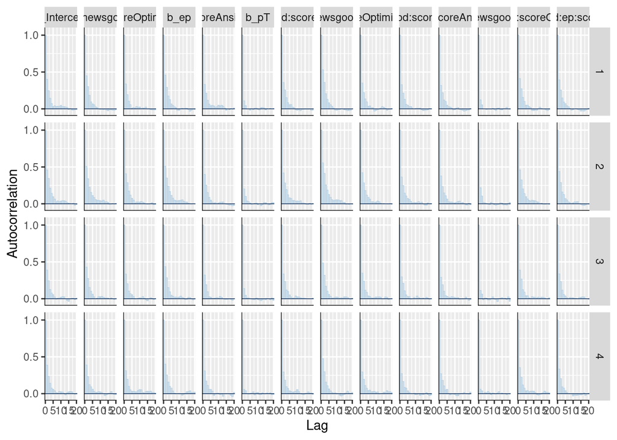

```r
mcmc_acf_bar(update_model, pars = vars(contains('b_')))
```

## ESS

```r
neff_ratio(update_model)
```

```
##                  b_Intercept                   b_newsgood
##                    0.2972603                    0.2846604
##             b_scoreOptimismo                         b_ep
##                    0.3378537                    0.2759179
##              b_scoreAnsiedad                         b_pT
##                    0.3618764                    0.7076188
##    b_newsgood:scoreOptimismo                b_newsgood:ep
##                    0.3235789                    0.2584301
##          b_scoreOptimismo:ep     b_newsgood:scoreAnsiedad
##                    0.3186389                    0.3698448
##           b_ep:scoreAnsiedad                b_newsgood:pT
##                    0.3767457                    0.7045632
## b_newsgood:scoreOptimismo:ep  b_newsgood:ep:scoreAnsiedad
##                    0.3006128                    0.3468641
##           sd_subj__Intercept                        sigma
##                    0.3508817                    1.1756671
##          r_subj[1,Intercept]          r_subj[2,Intercept]
##                    1.0009904                    0.9941074
##          r_subj[3,Intercept]          r_subj[4,Intercept]
##                    1.0411090                    0.8740635
##          r_subj[5,Intercept]          r_subj[6,Intercept]
##                    0.9475953                    0.8522194
##          r_subj[7,Intercept]          r_subj[8,Intercept]
##                    0.8038506                    0.9059255
##          r_subj[9,Intercept]         r_subj[10,Intercept]
##                    0.8425147                    0.9291272
##         r_subj[11,Intercept]         r_subj[12,Intercept]
##                    1.0118979                    0.9406299
##         r_subj[13,Intercept]         r_subj[14,Intercept]
##                    0.8862357                    0.9387047
##         r_subj[15,Intercept]         r_subj[16,Intercept]
##                    0.9523172                    0.9658979
##         r_subj[17,Intercept]         r_subj[18,Intercept]
##                    1.0154804                    0.8816891
##         r_subj[19,Intercept]         r_subj[20,Intercept]
##                    0.7903351                    0.8996797
##         r_subj[21,Intercept]         r_subj[22,Intercept]
##                    0.8644811                    1.0526084
##         r_subj[23,Intercept]         r_subj[24,Intercept]
##                    0.9172753                    0.8378614
##         r_subj[25,Intercept]         r_subj[26,Intercept]
##                    0.7128572                    0.9432807
##         r_subj[27,Intercept]         r_subj[28,Intercept]
##                    0.9306807                    0.8976424
##         r_subj[29,Intercept]         r_subj[30,Intercept]
##                    1.0018690                    0.9125420
##         r_subj[31,Intercept]         r_subj[32,Intercept]
##                    0.8523992                    1.0260723
##         r_subj[33,Intercept]                       lprior
##                    1.0205437                    0.2484686
##                         lp__
##                    0.2635527
```

## R-hat

```r
rhat(update_model)
```

```
##                  b_Intercept                   b_newsgood
##                    1.0004011                    1.0005998
##             b_scoreOptimismo                         b_ep
##                    1.0003945                    1.0005803
##              b_scoreAnsiedad                         b_pT
##                    1.0004325                    1.0003194
##    b_newsgood:scoreOptimismo                b_newsgood:ep
##                    1.0005286                    1.0007430
##          b_scoreOptimismo:ep     b_newsgood:scoreAnsiedad
##                    1.0002656                    1.0003797
##           b_ep:scoreAnsiedad                b_newsgood:pT
##                    1.0006675                    1.0003012
## b_newsgood:scoreOptimismo:ep  b_newsgood:ep:scoreAnsiedad
##                    1.0004456                    1.0006447
##           sd_subj__Intercept                        sigma
##                    1.0006758                    0.9999148
##          r_subj[1,Intercept]          r_subj[2,Intercept]
##                    1.0000976                    0.9999939
##          r_subj[3,Intercept]          r_subj[4,Intercept]
##                    0.9998870                    0.9999487
##          r_subj[5,Intercept]          r_subj[6,Intercept]
##                    0.9999827                    0.9998761
##          r_subj[7,Intercept]          r_subj[8,Intercept]
##                    1.0001879                    1.0000231
##          r_subj[9,Intercept]         r_subj[10,Intercept]
##                    1.0001729                    1.0000629
##         r_subj[11,Intercept]         r_subj[12,Intercept]
##                    0.9999171                    0.9999473
##         r_subj[13,Intercept]         r_subj[14,Intercept]
##                    1.0001035                    1.0000074
##         r_subj[15,Intercept]         r_subj[16,Intercept]
##                    1.0001548                    1.0000726
##         r_subj[17,Intercept]         r_subj[18,Intercept]
##                    0.9999412                    1.0001524
##         r_subj[19,Intercept]         r_subj[20,Intercept]
##                    0.9999316                    0.9999709
##         r_subj[21,Intercept]         r_subj[22,Intercept]
##                    1.0001809                    1.0001450
##         r_subj[23,Intercept]         r_subj[24,Intercept]
##                    1.0000992                    1.0000895
##         r_subj[25,Intercept]         r_subj[26,Intercept]
##                    1.0001456                    1.0002192
##         r_subj[27,Intercept]         r_subj[28,Intercept]
##                    1.0004481                    1.0003009
##         r_subj[29,Intercept]         r_subj[30,Intercept]
##                    1.0000163                    1.0001478
##         r_subj[31,Intercept]         r_subj[32,Intercept]
##                    1.0000390                    1.0000025
##         r_subj[33,Intercept]                       lprior
##                    0.9999641                    1.0007266
##                         lp__
##                    1.0007002
```

## Posterior predictive check

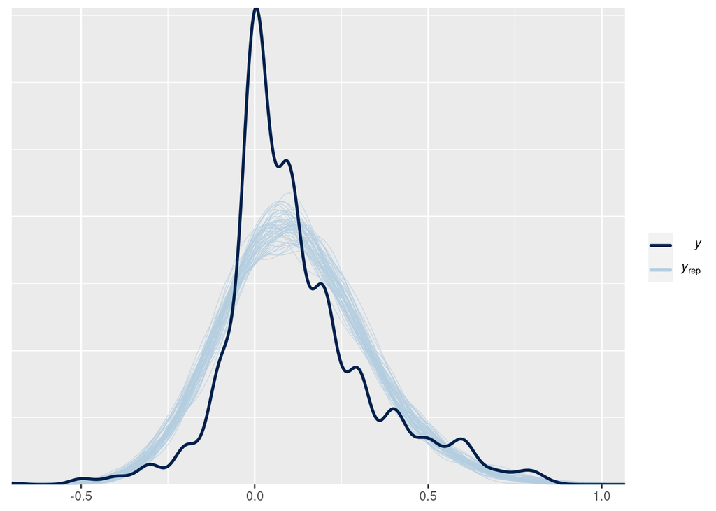

```r
brms::pp_check(update_model, ndraws = 50)
```

Ninguno de los diagnosticos hasta ahora parece arrojar nada preocupante pero el posterior predictive check muestra que el ajuste del modelo a los datos no es muy bueno. Es algo para discutir mas adelante.

# Resultados

Avanzamos con un resumen del modelo

## Posterior summary

```r
broom.mixed::tidy(update_model, conf.level = 0.95, conf.method = 'HPDinterval')
```

| effect | component | group | term | estimate | std.error | conf.low | conf.high |
| --- | --- | --- | --- | --- | --- | --- | --- |
| fixed | cond | NA | (Intercept) | 0.121173579 | 0.141613316 | -0.166124568 | 0.390316982 |
| fixed | cond | NA | newsgood | -0.372093870 | 0.174660205 | -0.711646413 | -0.026067324 |
| fixed | cond | NA | scoreOptimismo | -0.001724564 | 0.004728748 | -0.011090034 | 0.007299666 |
| fixed | cond | NA | ep | 1.503324729 | 0.502425261 | 0.512070433 | 2.476744969 |
| fixed | cond | NA | scoreAnsiedad | -0.001055022 | 0.002853719 | -0.006905001 | 0.004271007 |
| fixed | cond | NA | pT | -0.192491419 | 0.049968741 | -0.287164943 | -0.093800479 |
| fixed | cond | NA | newsgood:scoreOptimismo | 0.007887018 | 0.005690751 | -0.003464894 | 0.018891557 |
| fixed | cond | NA | newsgood:ep | -1.244616637 | 0.634555453 | -2.457091286 | 0.025039310 |
| fixed | cond | NA | scoreOptimismo:ep | -0.044406715 | 0.017188096 | -0.078808500 | -0.011526543 |
| fixed | cond | NA | newsgood:scoreAnsiedad | 0.002249997 | 0.003584396 | -0.004912411 | 0.009258726 |

[output cut: 6 more lines]

## Efectos Marginales

Ahora vamos a calcular los efectos que nos interesan. Estuve mucho tiempo batallando con esto asi que me parece bueno documentar el proceso y el aprendizaje para futuras referencias porque no logre encontrar mucha informacion al respecto (esa fue una de las principales dificultades).

### Efecto de las noticias

La pregunta para responder en este caso es ¿Cual es el efecto del tipo de noticia sobre el update? (marginalizando los valores de las otras covariadas)

Hay dos maneras de calcularlo. Una es utilizando el paquete `brmsmargins`.

```r
library(brmsmargins)
```

Usamos la funcion `brmsmargins` y aclaramos que queremos el efecto marginal del tipo de noticias con el argumento `at` y ajustando el contraste para hacer la comparacion. A su vez obtenemos el highest density interval del 95% de la posterior para cada estimacion de efecto.

```r
news_effect <- brmsmargins(
  update_model,
  at = data.frame(news = c('good', 'bad')),
  contrasts = cbind('AME news' = c(-1,1)),
  effects = "integrateoutRE", k = 100L, seed = 1234,
  CI = 0.95, CIType = "HDI"
)

news_effect$Summary
```

| M | Mdn | LL | UL | PercentROPE | PercentMID | CI | CIType | ROPE | MID |
| --- | --- | --- | --- | --- | --- | --- | --- | --- | --- |
| 0.15595647 | 0.15597611 | 0.13767006 | 0.1747259 | NA | NA | 0.95 | HDI | NA | NA |
| 0.09987097 | 0.09979623 | 0.07826298 | 0.1212010 | NA | NA | 0.95 | HDI | NA | NA |

Otra manera de calcular lo mismo es utilizando el paquete `marginaleffects`.

```r
library(marginaleffects)
options("marginaleffects_posterior_interval" = "hdi")
```

En este caso generamos predicciones con la funcion `predictions`. Las predicciones las hacemos sobre nuevos valores de random effects es decir con sujetos/datos que el modelo nunca vio. De esta manera se samplean de la distribucion poblacional de efectos random. Los sampleos se hacen sobre la distribucion posterior de la esperanza condicional usando la funcion `posterior_epred`. Esto implica que hay un nivel menos de incertidumbre que si samplearamos hasta el nivel de la variable de respuesta. [Los detalles de esta diferencia en el nivel de incerteza estan explicitados en el blog de Andrew Heiss](https://www.andrewheiss.com/blog/2022/09/26/guide-visualizing-types-posteriors/) pero basicamente se ignora la varianza de la distribucion normal que subyace a un modelo de regresion lineal normal. Un mismo valor de predictor puede dar muchas predicciones individuales distintas por la varianza de las predicciones pero da un solo valor de esperanza de la prediccion.

```r
predictions(
    update_model,
    newdata = datagrid(news = c('good','bad'), subj = -1:-100),
    allow_new_levels = TRUE,
    sample_new_levels = "gaussian")
```

| rowid | type | estimate | conf.low | conf.high | update | scoreOptimismo | ep | scoreAnsiedad | pT | news | subj |
| --- | --- | --- | --- | --- | --- | --- | --- | --- | --- | --- | --- |
| 1 | response | 0.15570404 | 0.08008932 | 0.2288085 | 0.118541 | 18.62787 | 0.2325369 | 26.65902 | 0.3034508 | good | -1 |
| 2 | response | 0.15583789 | 0.08170505 | 0.2311507 | 0.118541 | 18.62787 | 0.2325369 | 26.65902 | 0.3034508 | good | -2 |
| 3 | response | 0.15533281 | 0.07914602 | 0.2309683 | 0.118541 | 18.62787 | 0.2325369 | 26.65902 | 0.3034508 | good | -3 |
| 4 | response | 0.15531279 | 0.08167194 | 0.2322761 | 0.118541 | 18.62787 | 0.2325369 | 26.65902 | 0.3034508 | good | -4 |
| 5 | response | 0.15586453 | 0.08261574 | 0.2330436 | 0.118541 | 18.62787 | 0.2325369 | 26.65902 | 0.3034508 | good | -5 |
| 6 | response | 0.15560062 | 0.08101349 | 0.2288973 | 0.118541 | 18.62787 | 0.2325369 | 26.65902 | 0.3034508 | good | -6 |
| 7 | response | 0.15525853 | 0.08264013 | 0.2305476 | 0.118541 | 18.62787 | 0.2325369 | 26.65902 | 0.3034508 | good | -7 |
| 8 | response | 0.15559582 | 0.08373181 | 0.2316469 | 0.118541 | 18.62787 | 0.2325369 | 26.65902 | 0.3034508 | good | -8 |
| 9 | response | 0.15530995 | 0.08049605 | 0.2296901 | 0.118541 | 18.62787 | 0.2325369 | 26.65902 | 0.3034508 | good | -9 |
| 10 | response | 0.15513767 | 0.08187601 | 0.2289190 | 0.118541 | 18.62787 | 0.2325369 | 26.65902 | 0.3034508 | good | -10 |

[output cut: 190 more lines]

Para imitar el resultado obtenido con el paquete `brmsmargins` tenemos que promediar las estimaciones para cada tipo de noticia. Podemos hacerlo usando el argumento `by` dentro de la misma funcion.

```r
predictions(
    update_model,
    newdata = datagrid(news = c('good','bad'), subj = -1:-100),
    allow_new_levels = TRUE,
    sample_new_levels = "gaussian",
    by = 'news')
```

| type | news | estimate | conf.low | conf.high |
| --- | --- | --- | --- | --- |
| response | bad | 0.09794191 | 0.07529665 | 0.1203228 |
| response | good | 0.15541035 | 0.13576589 | 0.1753720 |

Comparando los resultados del paquete `brmsmargins` con los del paquete `marginaleffects` los resultados son muy similares.

Podemos proceder a comparar directamente el contraste obtenido con `brmsmargins` y el obtenido usando la funcion `avg_predictions` de `marginaleffects`.

```r
news_effect$ContrastSummary
```

| M | Mdn | LL | UL | PercentROPE | PercentMID | CI | CIType | ROPE | MID | Label |
| --- | --- | --- | --- | --- | --- | --- | --- | --- | --- | --- |
| -0.0560855 | -0.05611482 | -0.07890718 | -0.0342017 | NA | NA | 0.95 | HDI | NA | NA | AME news |

```r
avg_comparisons(
    update_model,
    newdata = datagrid(firm = -1:-100),
    allow_new_levels = TRUE,
    sample_new_levels = "gaussian", variables = 'news')
```

| type | term | contrast | estimate | conf.low | conf.high |
| --- | --- | --- | --- | --- | --- |
| response | news | good - bad | 0.05744502 | 0.03493921 | 0.07957878 |

El mismo resultado podemos obtenerlo con la funcion `avg_slopes`.

```r
avg_slopes(update_model, newdata = datagrid(firm = -1:-100),
    allow_new_levels = TRUE,
    sample_new_levels = "gaussian", variables = c('news'))
```

| type | term | contrast | estimate | conf.low | conf.high |
| --- | --- | --- | --- | --- | --- |
| response | news | good - bad | 0.05744502 | 0.03493921 | 0.07957878 |

Los valores son muy similares lo cual indica buena convergencia de los distintos metodos.

No obstante, es posible calcular los efectos marginales sin integrar los efectos random del modelo. Para hacer esto el proceso es muy similar solo que obviamos la mencion a los nuevos sujetos, cada uno con efectos random sampleados a partir de la distribucion general de efectos random (asumida como gaussiana).

Entonces por ejemplo para calcular el efecto marginal promedio de las noticias usamos de nuevo la funcion `predictions` pero excluimos el argumento `newdata` para agregar nuevos datos y los otros argumentos adicionales que controlan los efectos random.

```r
predictions(
    update_model,
    by = 'news',
    re_formula = NA)
```

| type | news | estimate | conf.low | conf.high |
| --- | --- | --- | --- | --- |
| response | bad | 0.06606008 | 0.04680272 | 0.0835456 |
| response | good | 0.16250801 | 0.14432092 | 0.1797051 |

En lineas generales los resultados se mantienen pero la diferencia es mucho mayor.

Para calcular directamente la diferencia (y los intervalos) usamos de nuevo la funcion `avg_slopes` y de nuevo excluimos todos los argumentos relativos a los nuevos datos.

```r
avg_slopes(update_model, variables = 'news')
```

| type | term | contrast | estimate | conf.low | conf.high |
| --- | --- | --- | --- | --- | --- |
| response | news | good - bad | 0.05611482 | 0.0342017 | 0.07890718 |

```r
news_effect$ContrastSummary
```

| M | Mdn | LL | UL | PercentROPE | PercentMID | CI | CIType | ROPE | MID | Label |
| --- | --- | --- | --- | --- | --- | --- | --- | --- | --- | --- |
| -0.0560855 | -0.05611482 | -0.07890718 | -0.0342017 | NA | NA | 0.95 | HDI | NA | NA | AME news |

Podemos comparar graficamente ambos metodos.

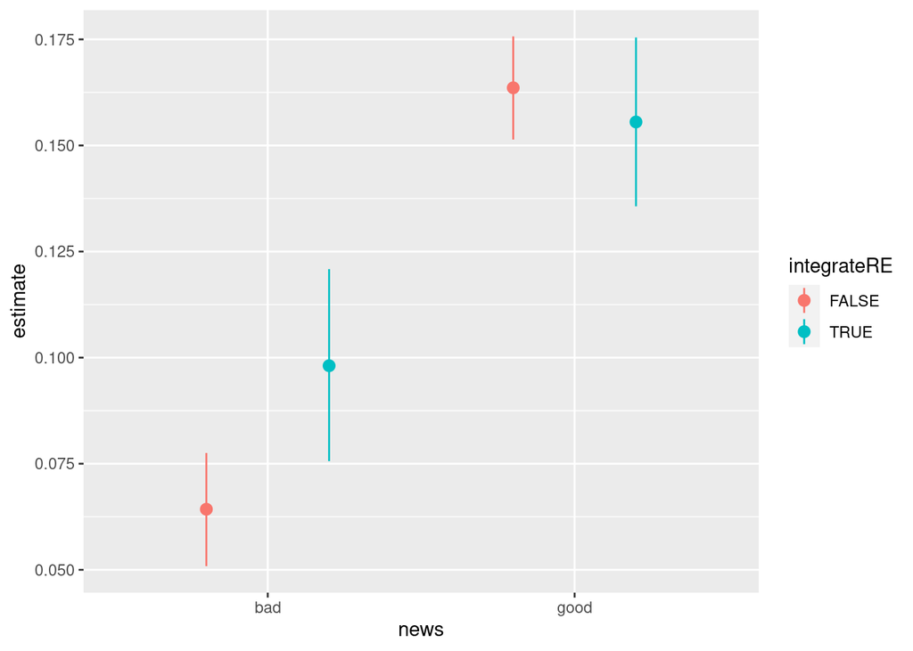

```r
news_effect_plotdata <- rbind(
  predictions(update_model, by = 'news') |> tidy(),
  predictions(
    update_model,
    newdata = datagrid(news = c('good','bad'), subj = -1:-100),
    allow_new_levels = TRUE,
    sample_new_levels = "gaussian",
    by = 'news') |> tidy()
) %>% mutate(integrateRE = rep(c(F,T), each = 2))

news_effect_plotdata %>%
  ggplot(
    aes(y = estimate, ymin = conf.low, ymax = conf.high, x = news, color = integrateRE)
    ) +
  geom_pointrange(position = position_dodge(.8))
```

En principio no hay grandes diferencias para las buenas noticias aunque la estimacion para las malas noticias muestra considerables diferencias con ambos metodos. Ahora podemos comparar los resultados de ambos metodos para el calculo de la diferencia (de manera directa).

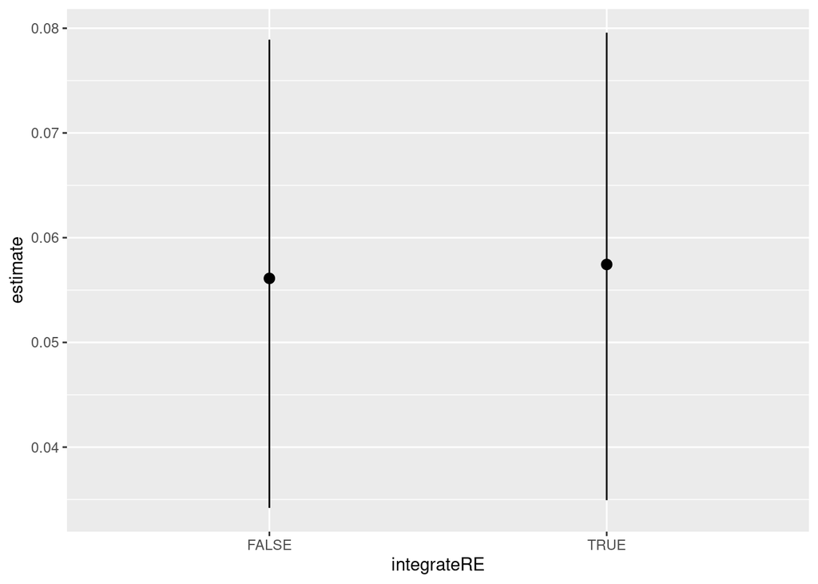

```r
news_effect_difference_plotdata <- rbind(
  avg_slopes(update_model, variables = 'news') |> broom.mixed::tidy(),
  avg_slopes(update_model, newdata = datagrid(firm = -1:-100),
    allow_new_levels = TRUE,
    sample_new_levels = "gaussian", variables = c('news')) |> broom.mixed::tidy()
) %>% mutate(integrateRE = c(F,T))

news_effect_difference_plotdata %>%
  ggplot(
    aes(x = integrateRE, y = estimate, ymin = conf.low, ymax = conf.high)
  ) +
  geom_pointrange()
```

Cuando calculamos la diferencia no vemos que haya una diferencia marcada, valga la redundancia, entre ambos metodos. Considerando esto de ahora en mas no vamos a integrar los efectos aleatorios del modelo.

## Prediction Error

En este caso no tenemos un predictor categorico sino continuo. Lo que nos interesa entonces es entender el efecto del incremento del error de prediccion independientemente de la no-linealidad del modelo (las interacciones).

Primero calculamos el efecto general del prediction error que siguiendo la definicion del paquete `marginaleffects` equivale a la derivada parcial de la regresion con respecto al regresor de interes.

```r
avg_slopes(update_model, variables = c("ep"))
```

| type | term | estimate | conf.low | conf.high |
| --- | --- | --- | --- | --- |
| response | ep | 0.5779859 | 0.5146925 | 0.6428172 |

Ahora procedemos a calcular de nuevo el efecto del error de prediccion y por efecto nos referimos a la derivada parcial de la pendiente pero esta vez diferenciando para los dos tipos de noticias ya que dado la interaccion pensamos que los distintos tipos de noticias nos marcan distintos efectos sobre el error de prediccion.

```r
avg_slopes(update_model, variables = c("ep"), by = c('news'))
```

| type | term | contrast | news | estimate | conf.low | conf.high | predicted | predicted_hi | predicted_lo | tmp_idx |
| --- | --- | --- | --- | --- | --- | --- | --- | --- | --- | --- |
| response | ep | mean(dY/dX) | bad | 0.3961020 | 0.2751903 | 0.5111668 | 0.06660663 | 0.06663498 | 0.06660663 | 1 |
| response | ep | mean(dY/dX) | good | 0.7289894 | 0.6658896 | 0.7983998 | 0.07495715 | 0.07502498 | 0.07495715 | 26 |

Graficamos la diferencia en las pendientes de dos maneras distintas. Por un lado el efecto del error de prediccion sobre la variable de respuesta para cada tipo de noticia y por el otro lado graficando especificamente la diferencia en las pendientes.

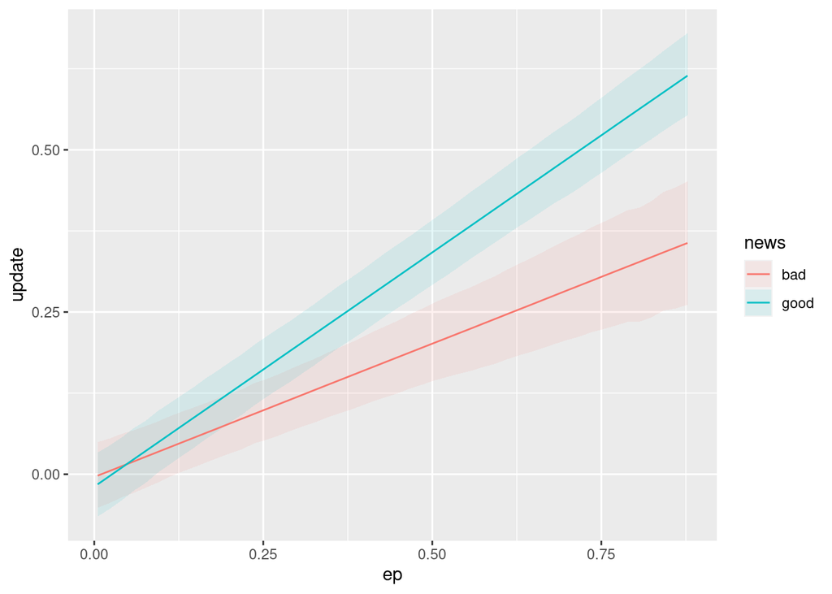

```r
plot_predictions(update_model, condition = c("ep", "news"), re_formula = NULL)
```

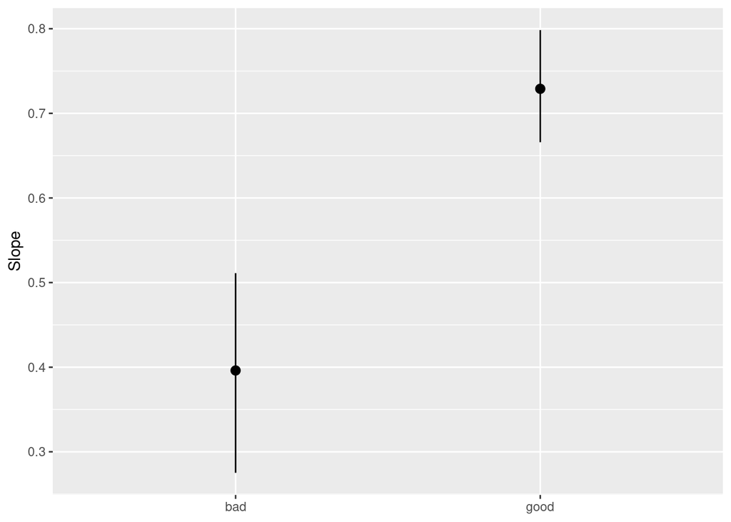

```r
plot_slopes(update_model, variables = 'ep', by = 'news')
```

## Optimismo

Este caso es similar al del error de prediccion. Primero calculamos el efecto marginal general del optimismo.

```r
avg_slopes(update_model, variables = 'scoreOptimismo')
```

| type | term | estimate | conf.low | conf.high |
| --- | --- | --- | --- | --- |
| response | scoreOptimismo | -0.003857477 | -0.009595967 | 0.001738652 |

Despues calculamos el efecto marginal (la derivada parcial de la pendiente) sobre el optimismo para los dos tipos de noticias.

```r
avg_slopes(update_model, variables = c("scoreOptimismo"), by = c('news'))
```

| type | term | contrast | news | estimate | conf.low | conf.high | predicted | predicted_hi | predicted_lo | tmp_idx |
| --- | --- | --- | --- | --- | --- | --- | --- | --- | --- | --- |
| response | scoreOptimismo | mean(dY/dX) | bad | -0.010434071 | -0.017048538 | -0.003934225 | 0.06660663 | 0.06657506 | 0.06660663 | 1 |
| response | scoreOptimismo | mean(dY/dX) | good | 0.001602165 | -0.005002236 | 0.008082740 | 0.07495715 | 0.07496383 | 0.07495715 | 26 |

El efecto no cambia cuando integramos los efectos random.

```r
avg_slopes(update_model, newdata = datagrid(news = c('good','bad'), subj = -1:-100),
    allow_new_levels = TRUE,
    sample_new_levels = "gaussian",
    variables = c("scoreOptimismo"), by = c('news'))
```

| type | term | contrast | news | estimate | conf.low | conf.high | predicted | predicted_hi | predicted_lo | tmp_idx |
| --- | --- | --- | --- | --- | --- | --- | --- | --- | --- | --- |
| response | scoreOptimismo | mean(dY/dX) | good | 0.002104021 | -0.004435159 | 0.008581237 | 0.15530593 | 0.15545451 | 0.15544793 | 1 |
| response | scoreOptimismo | mean(dY/dX) | bad | -0.012052820 | -0.018525819 | -0.005130682 | 0.09764996 | 0.09819836 | 0.09821348 | 101 |

Graficamos

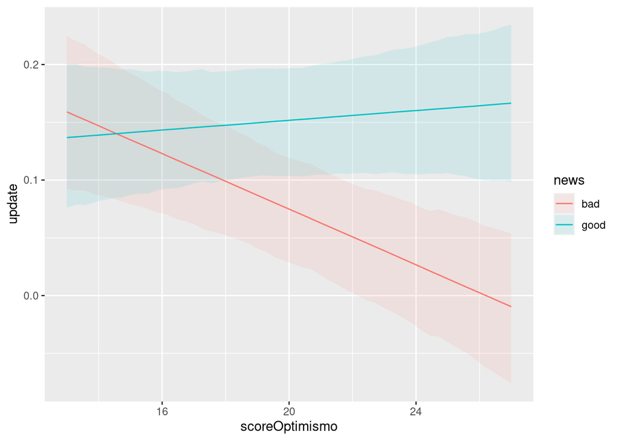

```r
plot_predictions(update_model, condition = c("scoreOptimismo", "news"))
```

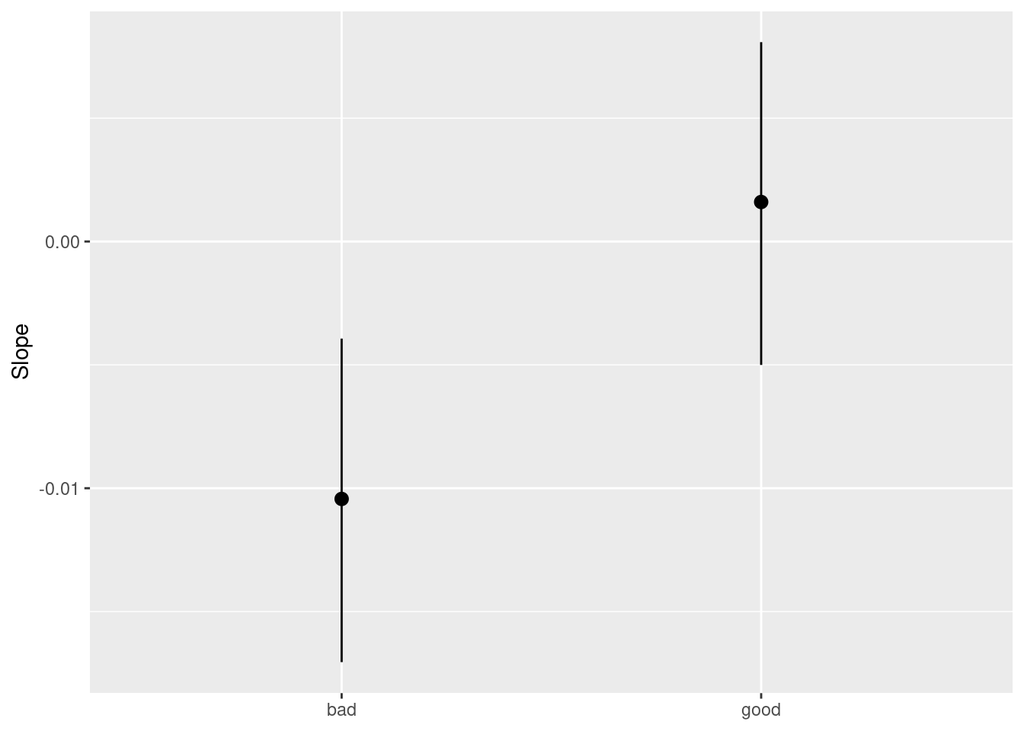

```r
plot_slopes(update_model, variables = 'scoreOptimismo', by = 'news')
```

Diferencia en la pendiente segun valor de prediction error por tipo de noticia

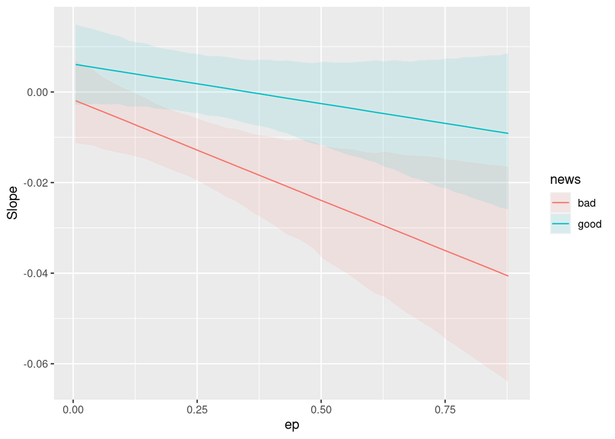

```r
plot_slopes(update_model, variables = 'scoreOptimismo', condition = c('ep','news'))
```

## Ansiedad

Primero calculamos el efecto (la derivada parcial de la pendiente) sobre la ansiedad de manera general.

```r
avg_slopes(update_model, variables = 'scoreAnsiedad')
```

| type | term | estimate | conf.low | conf.high |
| --- | --- | --- | --- | --- |
| response | scoreAnsiedad | 0.003521126 | -2.288185e-06 | 0.007054946 |

Ahora calculamos el efecto marginal (la derivada parcial de la pendiente) de la ansiedad para los dos tipos de noticias.

```r
avg_slopes(update_model, variables = c("scoreAnsiedad"), by = c('news'))
```

| type | term | contrast | news | estimate | conf.low | conf.high | predicted | predicted_hi | predicted_lo | tmp_idx |
| --- | --- | --- | --- | --- | --- | --- | --- | --- | --- | --- |
| response | scoreAnsiedad | mean(dY/dX) | bad | -0.003011033 | -0.007019825 | 0.001186752 | 0.06660663 | 0.06659617 | 0.06660663 | 1 |
| response | scoreAnsiedad | mean(dY/dX) | good | 0.008963540 | 0.004973952 | 0.013185150 | 0.07495715 | 0.07497341 | 0.07495715 | 26 |

El efecto no cambia cuando integramos los efectos random.

```r
avg_slopes(
  update_model,
  newdata = datagrid(news = c('good','bad'), subj = -1:-100),
  allow_new_levels = TRUE,
  sample_new_levels = "gaussian",
  variables = 'scoreAnsiedad', by = 'news'
)
```

| type | term | contrast | news | estimate | conf.low | conf.high | predicted | predicted_hi | predicted_lo | tmp_idx |
| --- | --- | --- | --- | --- | --- | --- | --- | --- | --- | --- |
| response | scoreAnsiedad | mean(dY/dX) | good | 0.008058479 | 0.003962354 | 0.0121853879 | 0.15551370 | 0.15546668 | 0.15545513 | 1 |
| response | scoreAnsiedad | mean(dY/dX) | bad | -0.003371515 | -0.007367054 | 0.0009768063 | 0.09787188 | 0.09784133 | 0.09785138 | 101 |

Graficamos

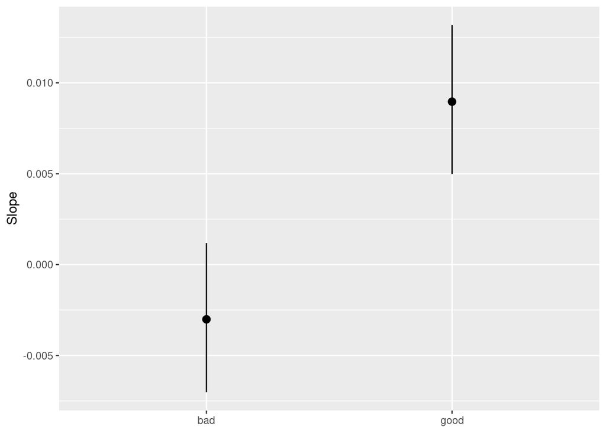

```r
plot_slopes(update_model, variables = 'scoreAnsiedad', by = 'news')
```

Diferencia en la pendiente segun valor de prediction error por tipo de noticia

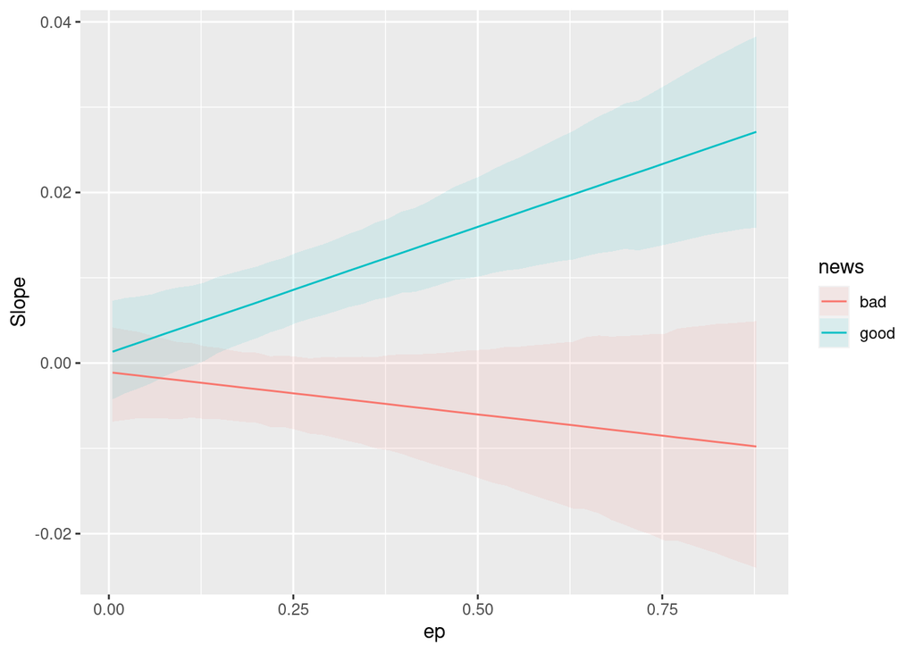

```r
plot_slopes(update_model, variables = 'scoreAnsiedad', condition = c('ep','news'))
```

## Sensitivity Analysis

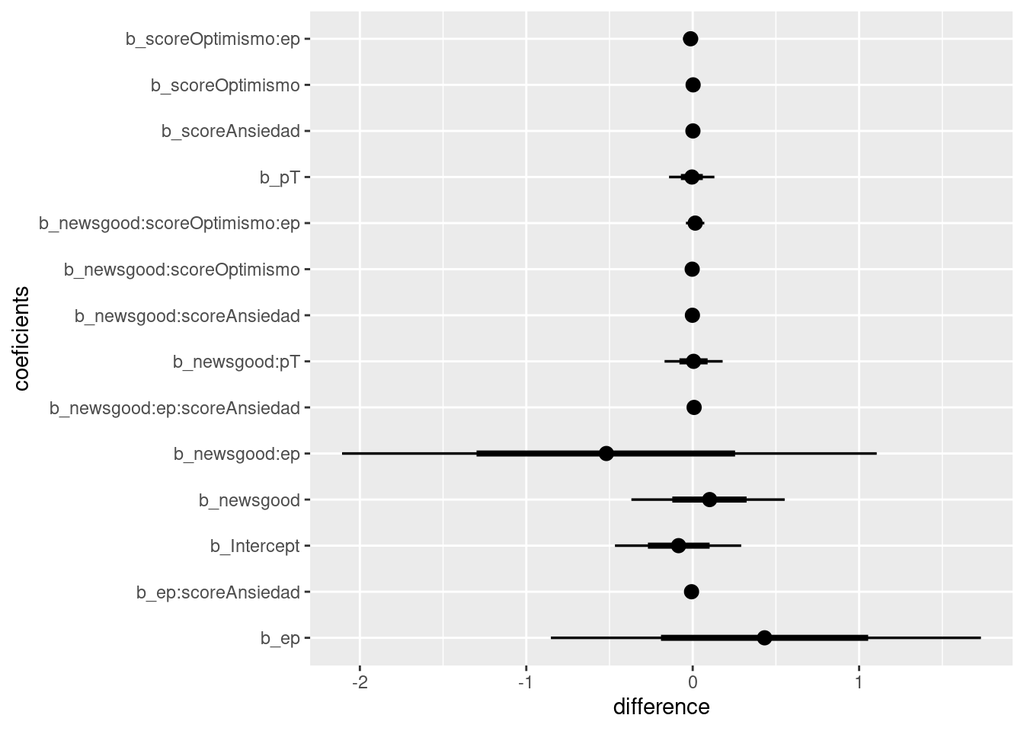

```r
small_priors <- c(
  set_prior('normal(0,1)', class = 'b')
)

update_sensitivity_model <- brm(update ~
                news * scoreOptimismo * ep +
                news * scoreAnsiedad * ep +
                news * pT +
                (1 | subj),
              data = dexp1,
              seed = 1234, # for reproducibility
              cores = 4, chains = 4,
              prior = small_priors,
              iter = 10000,
              file = "model_fits/FitExp1_sensitivity"
)


(
  tidybayes::tidy_draws(update_model) |> select(matches('b_')) - tidybayes::tidy_draws(update_sensitivity_model) |> select(matches('b_')) ) |>
  pivot_longer(cols = everything(), names_to = 'coeficients', values_to = 'difference') |>
  ggplot(
  aes(y = coeficients, x = difference)
) + stat_pointinterval()
```

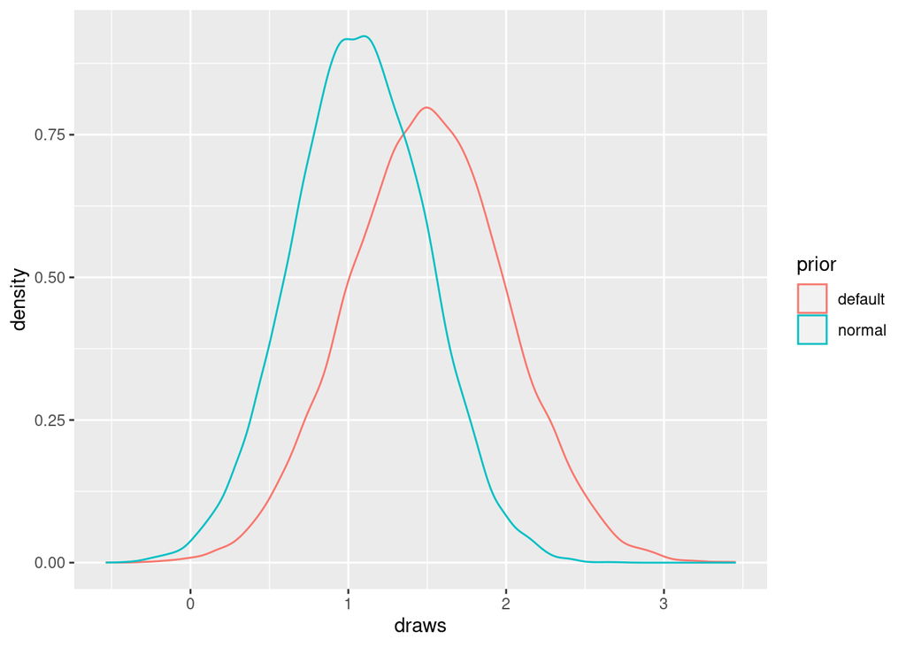

```r
data.frame(
  draws = c(
    tidybayes::tidy_draws(update_model) |> pull(`b_ep`),
    tidybayes::tidy_draws(update_sensitivity_model) |> pull(`b_ep`)
    ),
  prior = rep(c('default','normal'), each = 20000)
) |>
  ggplot(
    aes(x = draws, color = prior)
  ) +
  geom_density()
```